# The Manner of Activity Prediction

## Synopsis

Using devices such as Jawbone Up, Nike FuelBand and Fitbit it is now possible to collect a large amount of data about personal activity relatively inexpensively. These type of devices are part of the quantified self movement, a group of enthusiasts who take measurements about themselves regularly to improve their health, to find patterns in their behavior, or because they are tech geeks. One thing that people regularly do is quantify how much of a particular activity they do, but they rarely quantify how well they do it. The goal of this project will be to use data from accelerometers on the belt, forearm, arm, and dumbbell of 6 participants and predict the manner in which they did the exercise. They were asked to perform barbell lifts correctly and incorrectly in 5 different ways: Exactly according to the specification (Class A), Throwing the elbows to the front (Class B), Lifting the dumbbell only halfway (Class C), Lowering the dumbbell only halfway (Class D), Throwing the hips to the front (Class E).

## Data Processing

Set the seed for optim reproducibility and read the data. Resolving, in the same time, the issues with mising or deformed entries.

```r
seed <- as.numeric(as.Date("11-11-2015"))
set.seed(seed)
data_training <- read.csv('http://d396qusza40orc.cloudfront.net/predmachlearn/pml-training.csv', na.strings=c("NA","#DIV/0!",""))
#View(data_training)
```

Data exploration:

```r
table(data_training$classe)
```

```
##
##    A    B    C    D    E
## 5580 3797 3422 3216 3607
```

```r
prop.table(table(data_training$user_name, data_training$classe), 1)
```

```
##
##                    A         B         C         D         E
##   adelmo   0.2993320 0.1993834 0.1927030 0.1323227 0.1762590
##   carlitos 0.2679949 0.2217224 0.1584190 0.1561697 0.1956941
##   charles  0.2542421 0.2106900 0.1524321 0.1815611 0.2010747
##   eurico   0.2817590 0.1928339 0.1592834 0.1895765 0.1765472
##   jeremy   0.3459730 0.1437390 0.1916520 0.1534392 0.1651969
##   pedro    0.2452107 0.1934866 0.1911877 0.1796935 0.1904215
```

```r
prop.table(table(data_training$classe))
```

```
##
##         A         B         C         D         E
## 0.2843747 0.1935073 0.1743961 0.1638977 0.1838243
```

The description of the project states that “your goal will be to use data from accelerometers on the belt, forearm, arm, and dumbell of 6 participants”, that implies that I can delete first 7 columns. My understanding is that the columns before roll_ belt such as cvtd_timestamp were used by the initial researchers to keep track of how the data were collected. They have NOTHING to do with the task at hand, which is to predict which of the five categories of classe the row falls into based on the SENSOR data. Explore and preprocess the data:

```r
library(caret)
data_training <- data_training[, -(1:7)]
#we can see many columns with Na's
sum(is.na(data_training))
```

```
## [1] 1925102
```

```r
#there are way to many NA's. I will create a function which will show
#which variables are containing them
#you can use: lapply(data_training, function(x) sum(is.na(x))) or
show <- colSums(is.na(data_training))
#we can see that where we have NA's, those columns are almost totaly full of them, so we are safe if I remove those columns
#now I will keep just those variables with data
data_training <- data_training[, show == 0]

#find and remove corelated variables/centering and scaling the data
findCorrelation(cor(data_training[,-53]), cutoff = .9, names = T)
```

```
## [1] "accel_belt_z"     "roll_belt"        "accel_belt_y"
## [4] "accel_belt_x"     "gyros_dumbbell_x" "gyros_dumbbell_z"
## [7] "gyros_arm_x"
```

```r
data_training <- data_training[, -c(10, 1, 9, 8, 31, 33, 18)]

#looking for near zero variables
nzv <- nearZeroVar(data_training, saveMetrics=TRUE)
if (any(nzv$nzv)) nzv else message("No variables with near zero variance")
```

```
## No variables with near zero variance
```

```r
#dim(data_training)
#[1] 19622    46
```

```r
#predicting with decision trees
library(rpart)
library(tree)
#tree <- rpart(classe ~ ., data=training, method="class") why this doen't work with cv.tree function?
rtree <- tree(classe ~ ., data=training, method="class")
rtree_valid <- predict(rtree, validation, type = 'class')
first <- confusionMatrix(rtree_valid, validation$classe)
overall <- first$overall
overall['Accuracy']
```

```
##  Accuracy
## 0.6531861
```

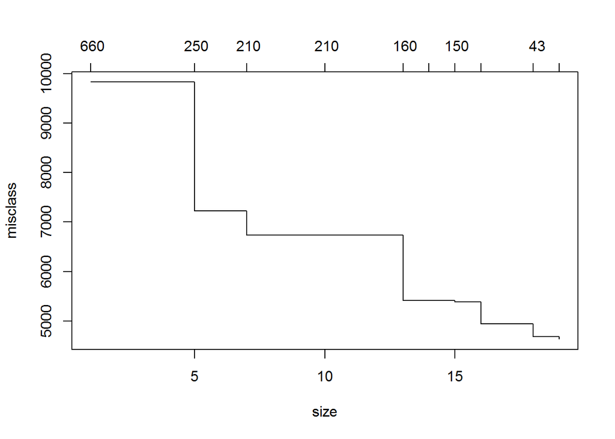

```r
#this tree at full depth might be too variable. I use cross-validation
#to prune it.
cv_tree <- cv.tree(rtree, FUN = prune.misclass)
plot(cv_tree)
```